# Fatal opioid-detected overdoses in Region 5, 2018-2023

#### 2022

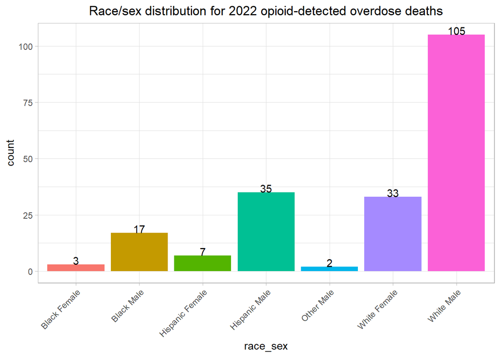

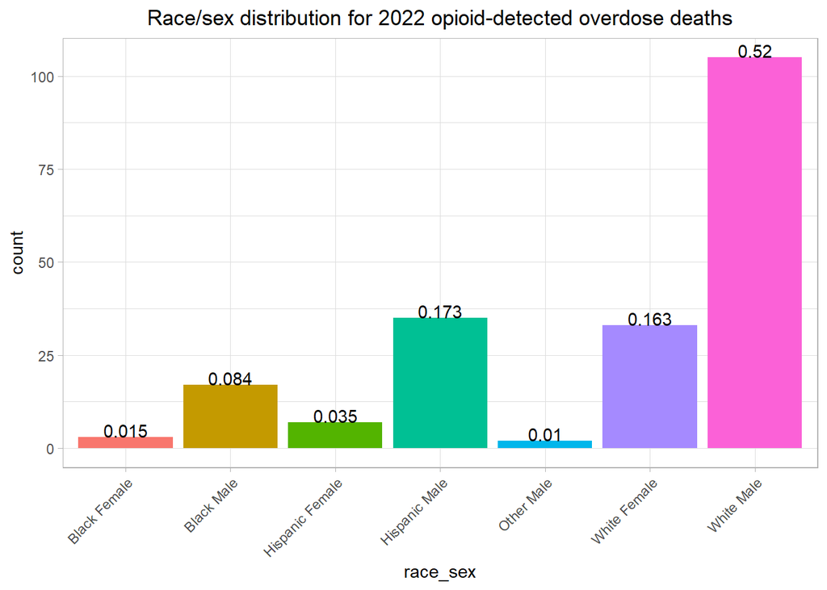

#### 2023

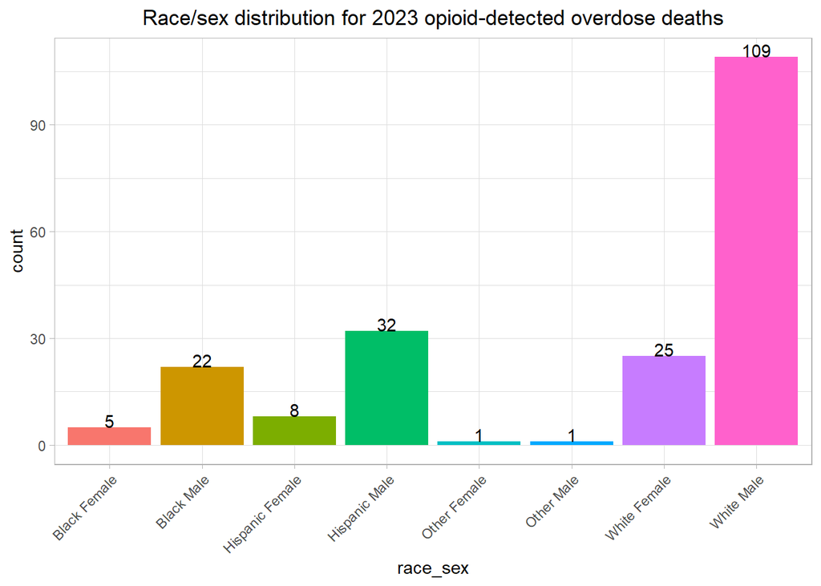

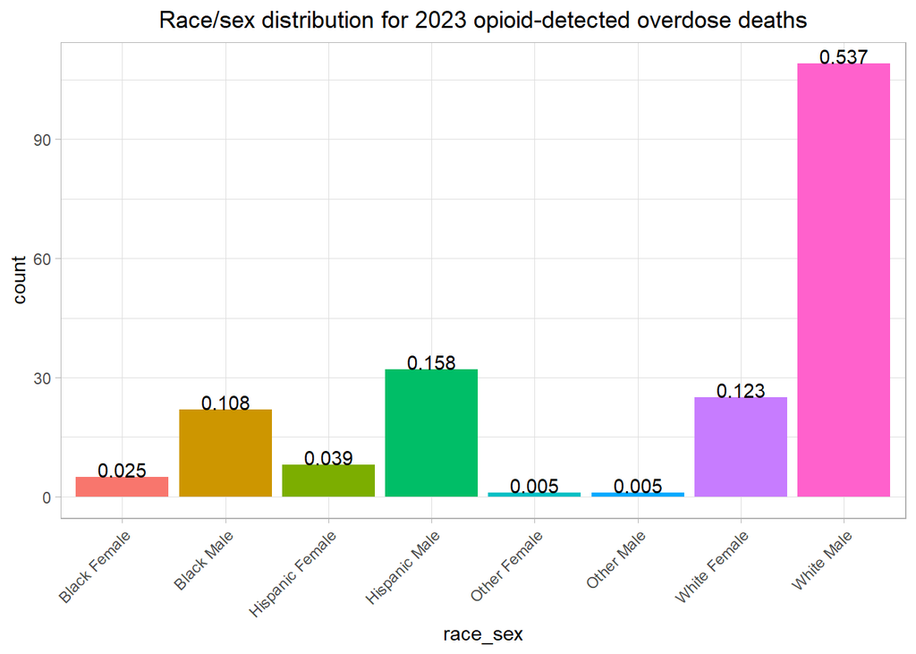

### Age

#### 2018

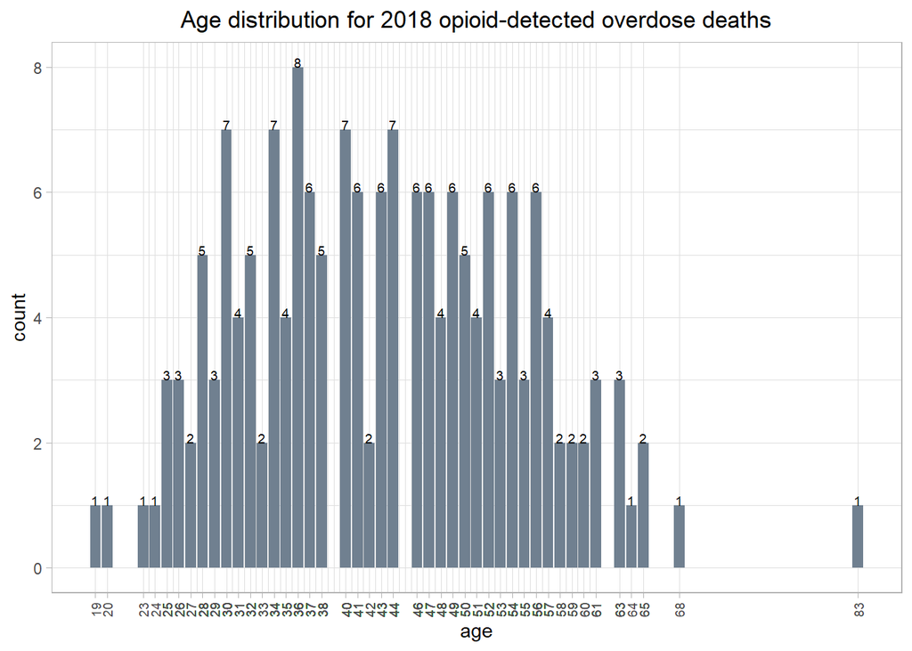

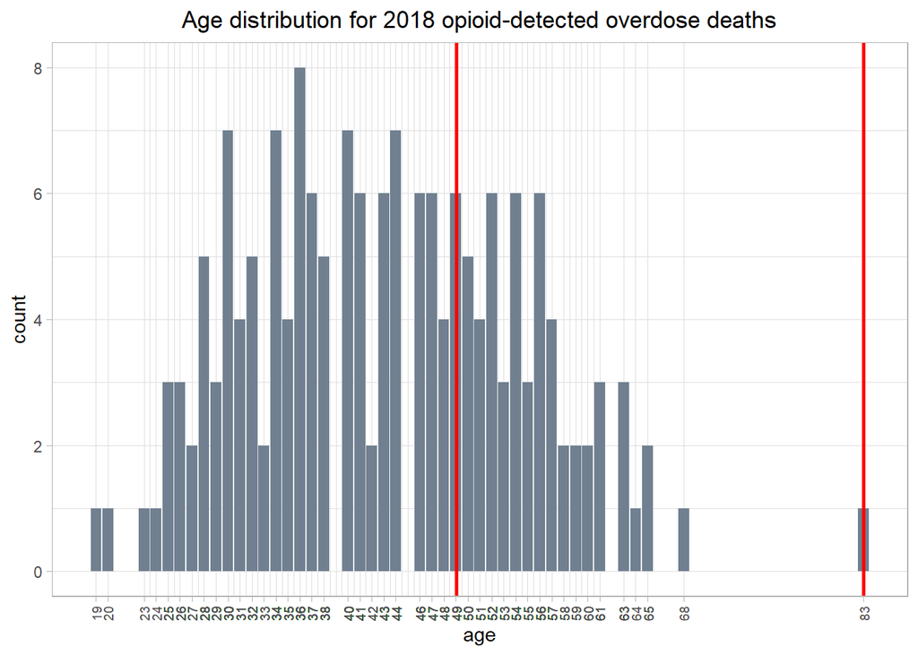

#### 2019

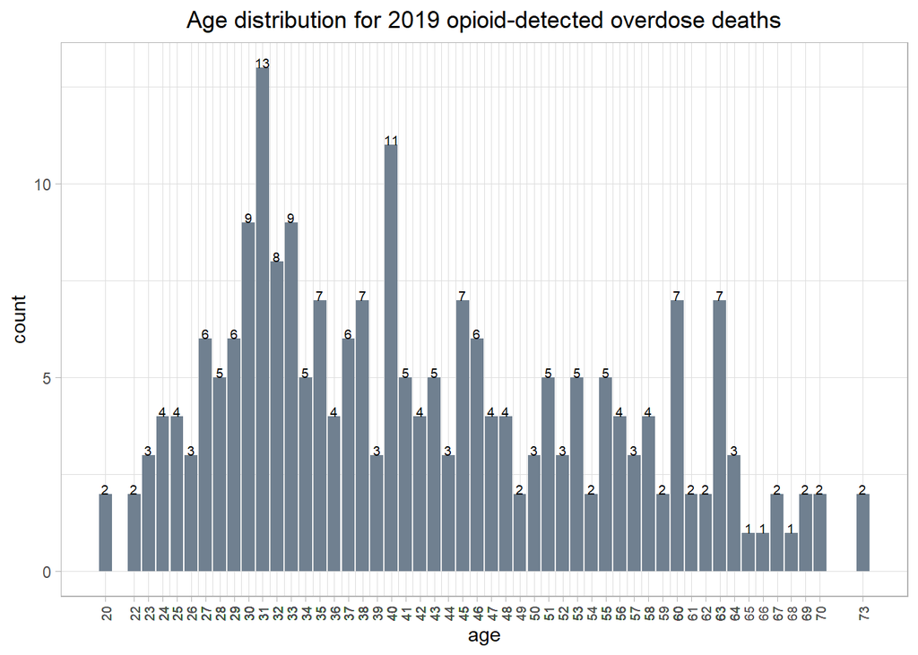

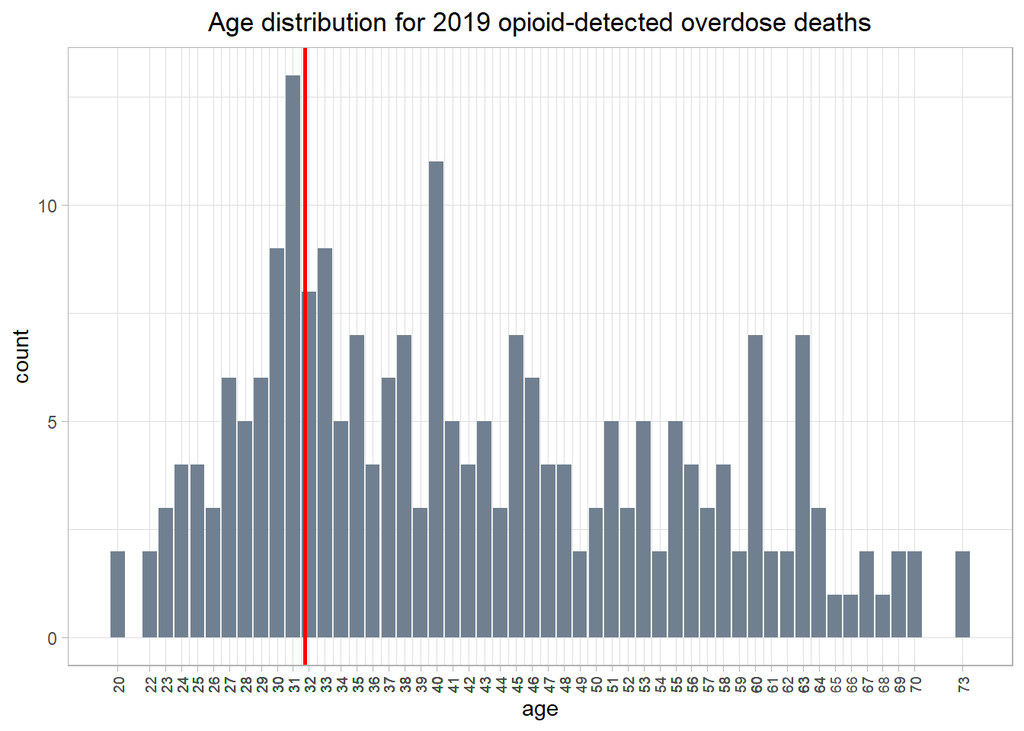

#### 2020

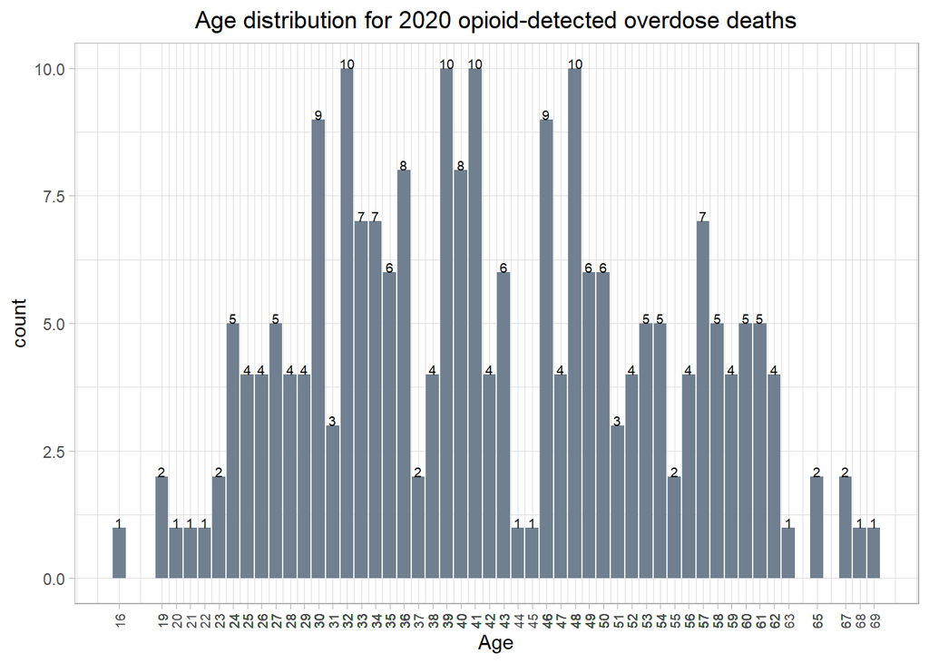

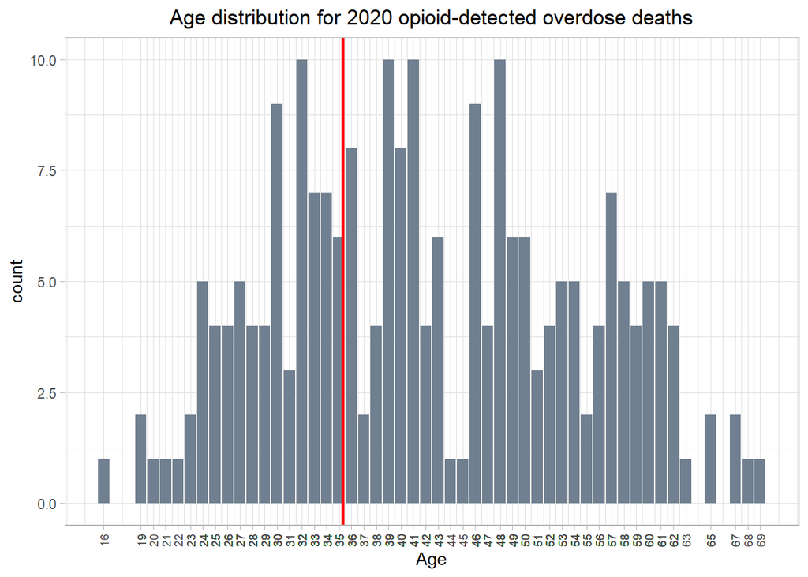

#### 2021

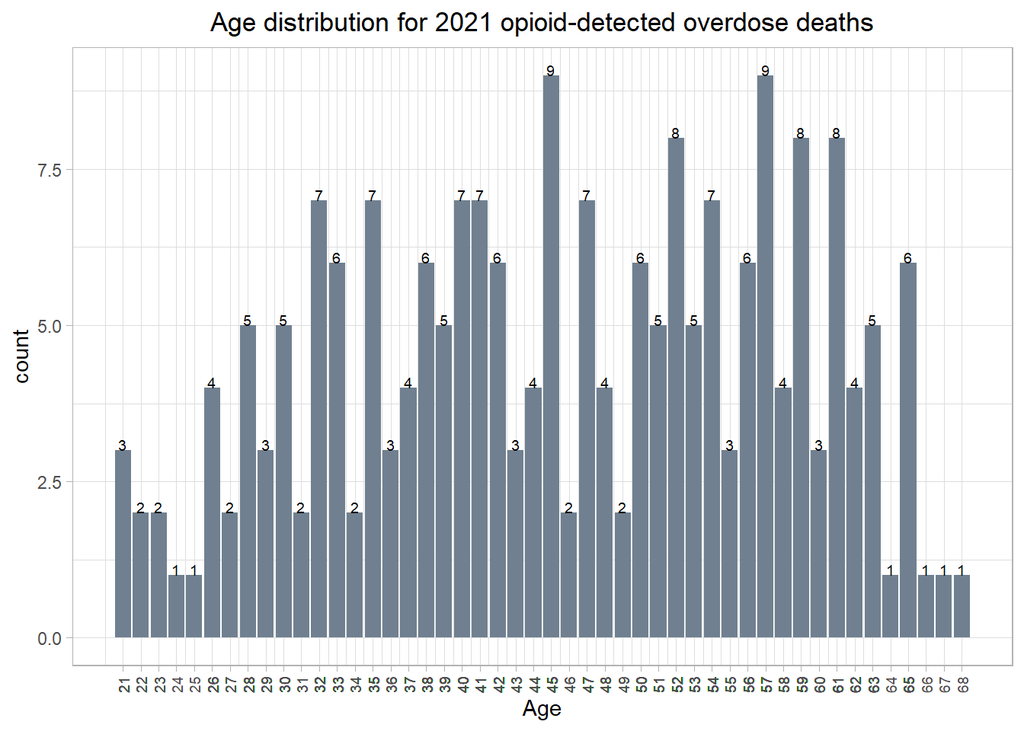

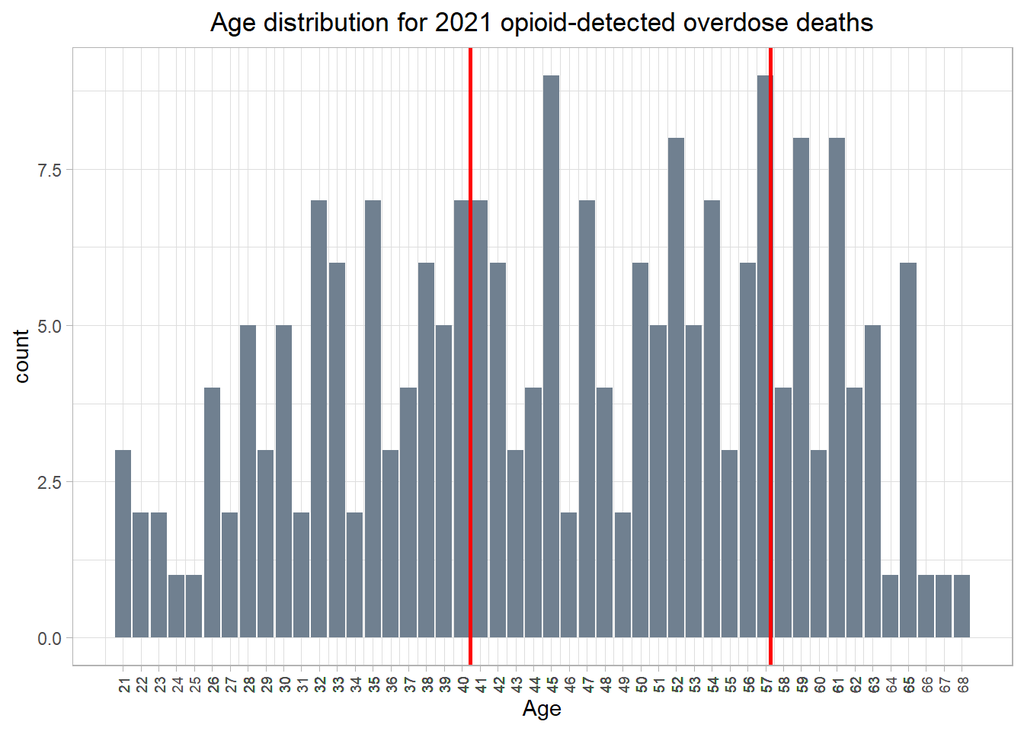

#### 2022

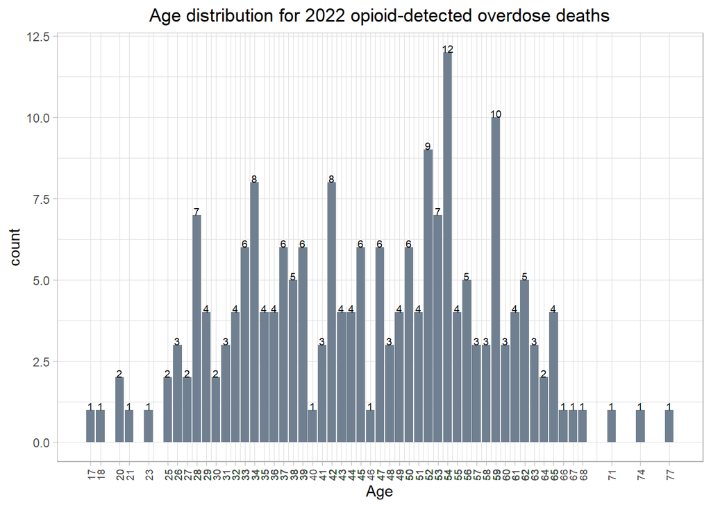

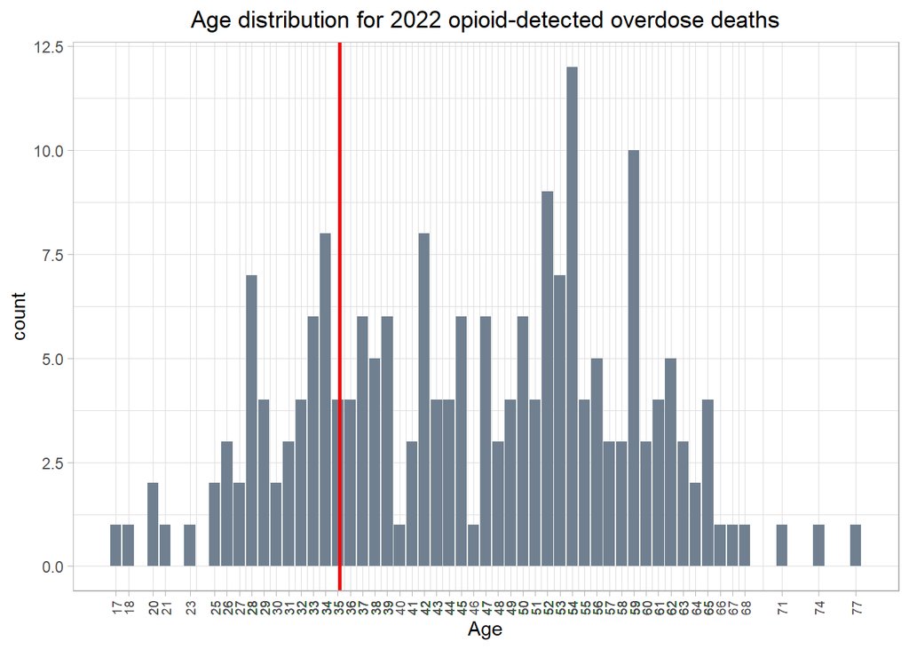

#### 2023

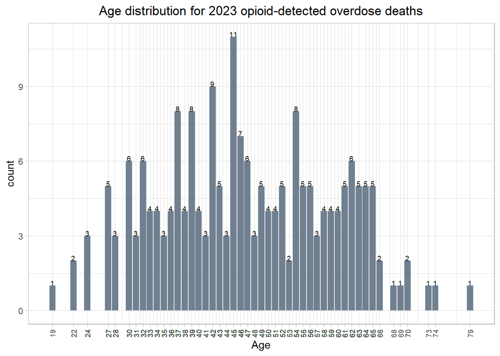

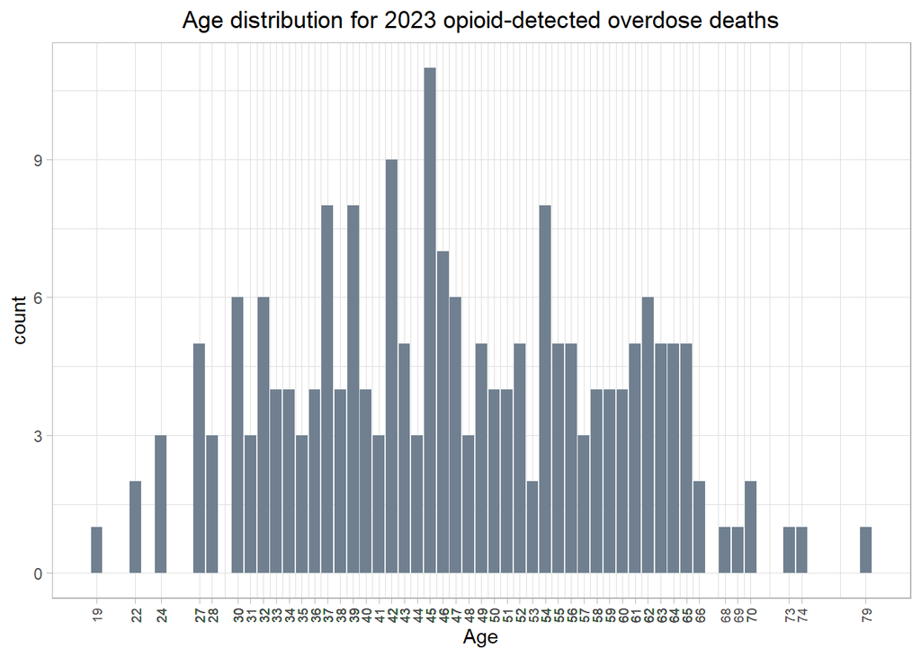

### Day of week

While there isn’t a clear trend for fatal overdoses, it is worth noting that there are more nonfatal overdoses on Friday and Saturday [analysis done with DPH’s EMS data]. I do not see any trends in day of week for 2009-2017 either [data to be published].

#### 2018

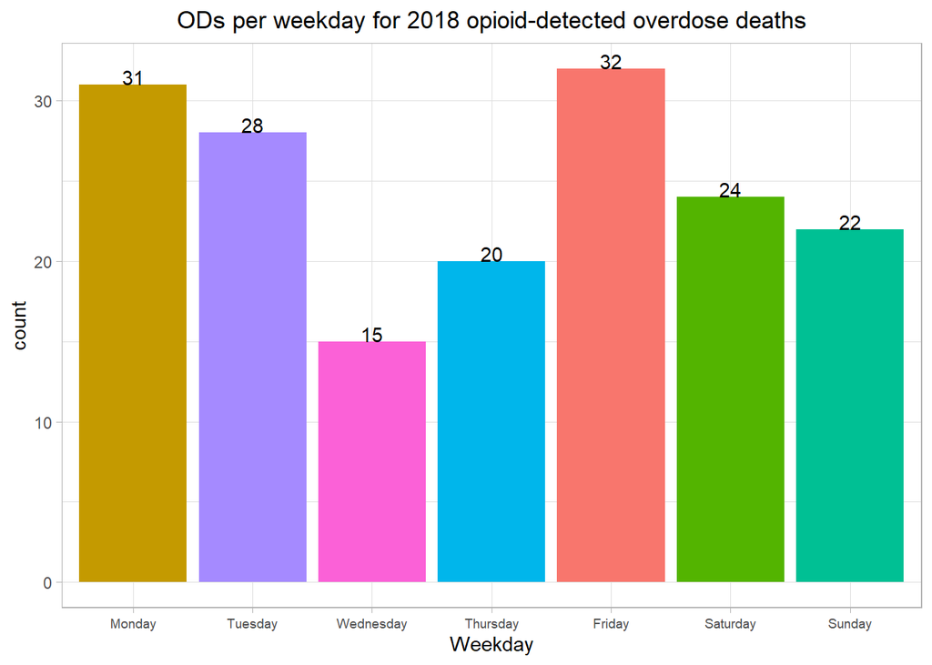

#### 2019

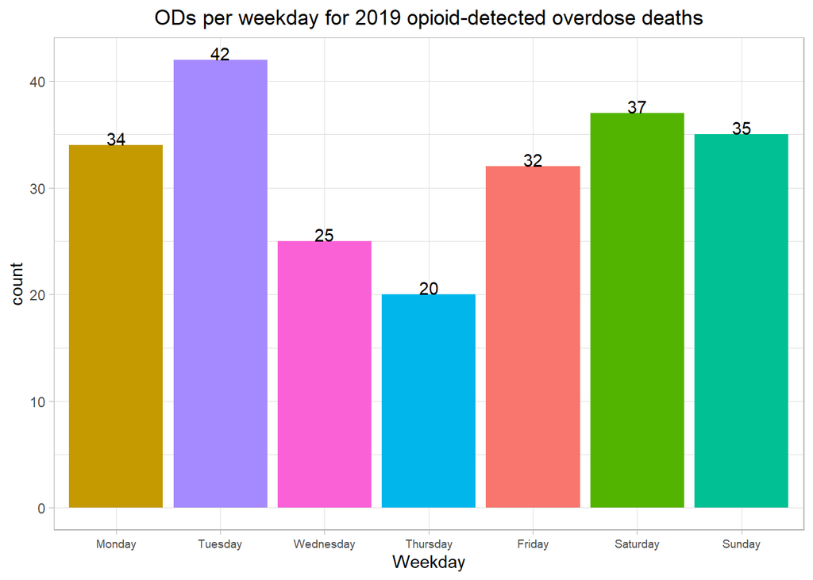

#### 2020

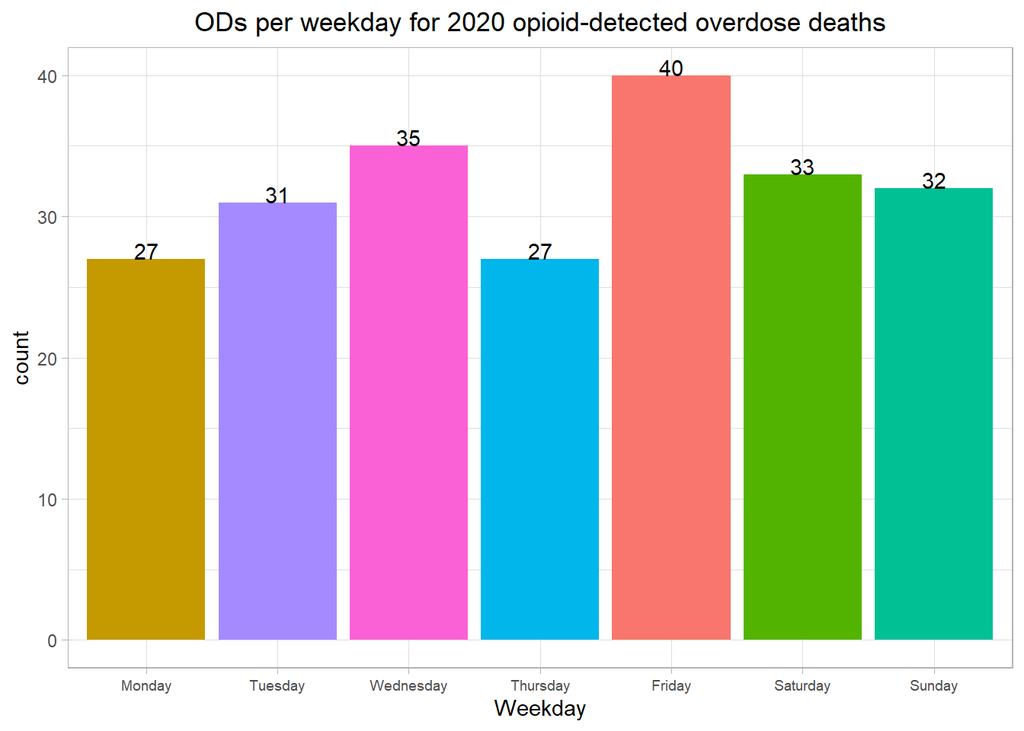

#### 2021

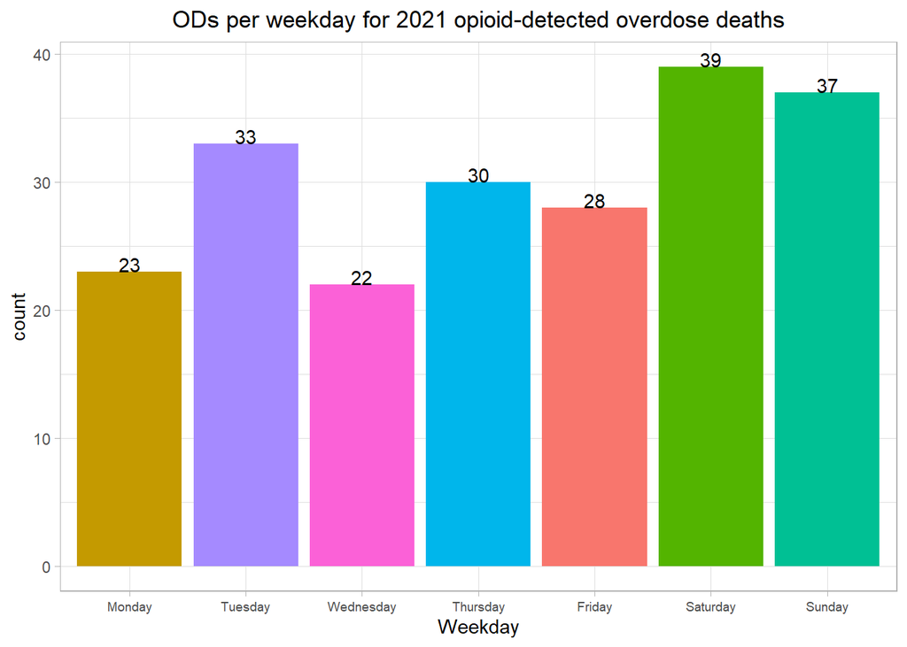

#### 2022

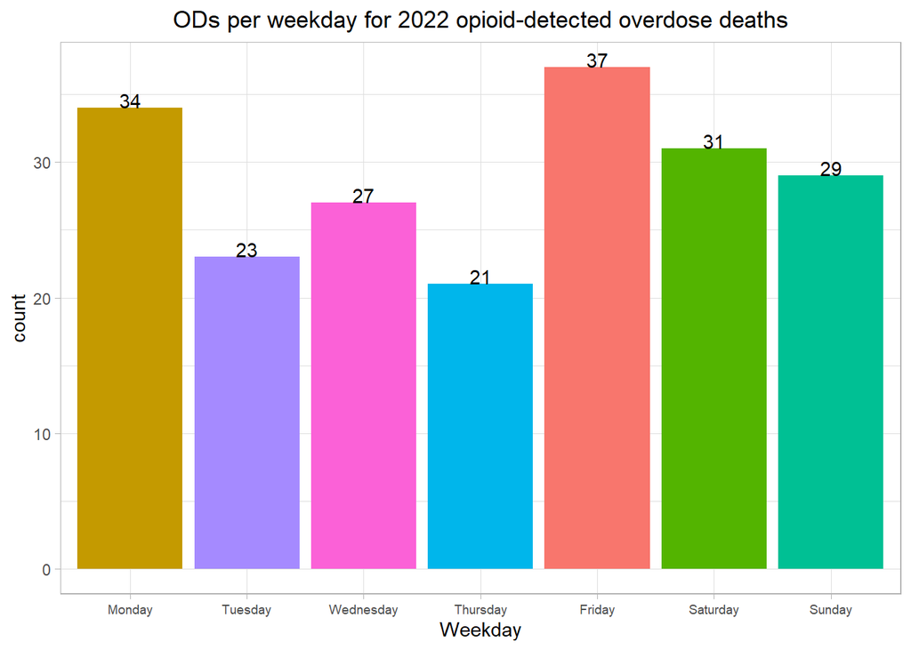

#### 2023

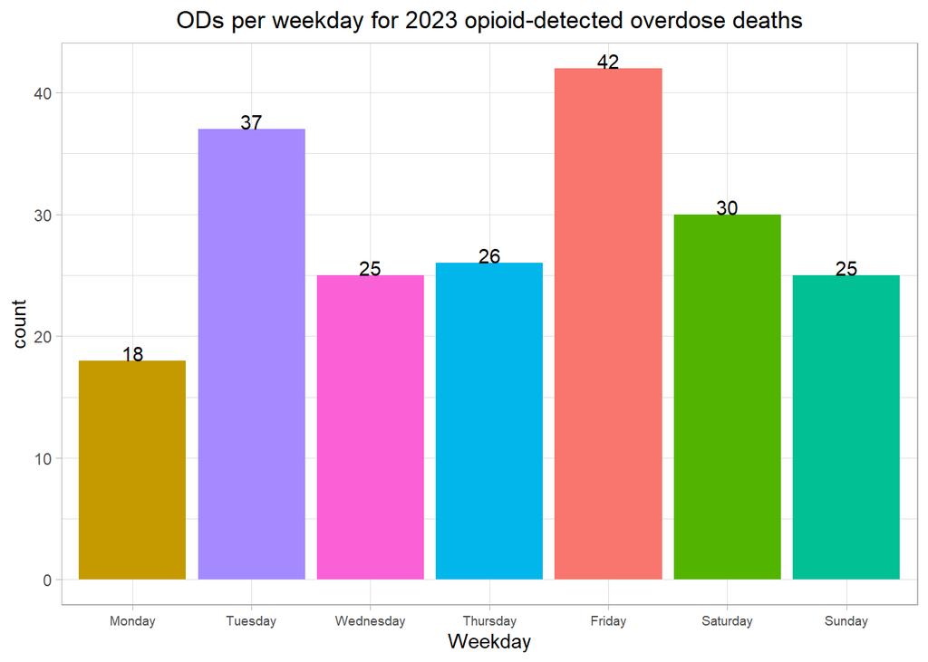

### Month

I do not see trends in month of overdose for 2009-2017 either.

#### 2018

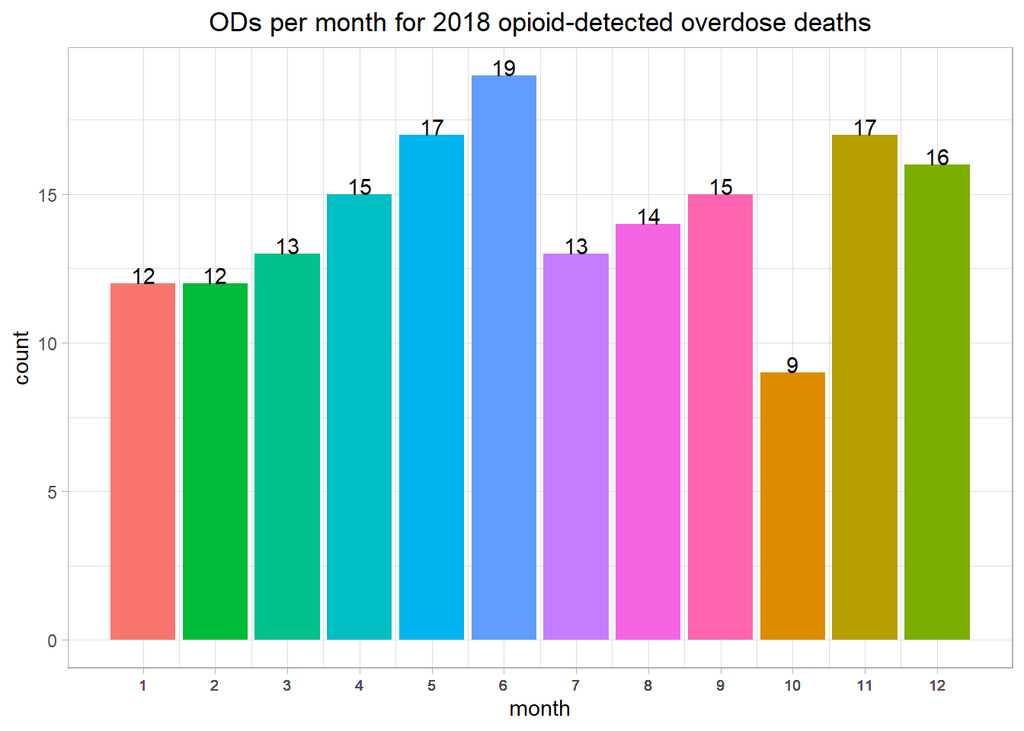

#### 2019

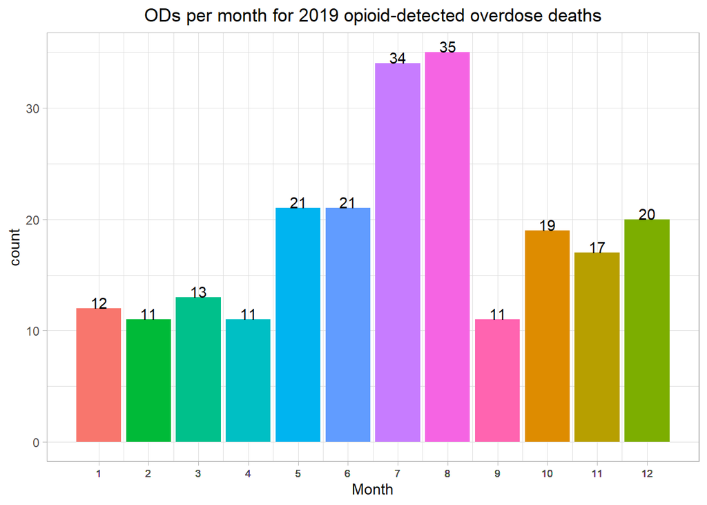

#### 2020

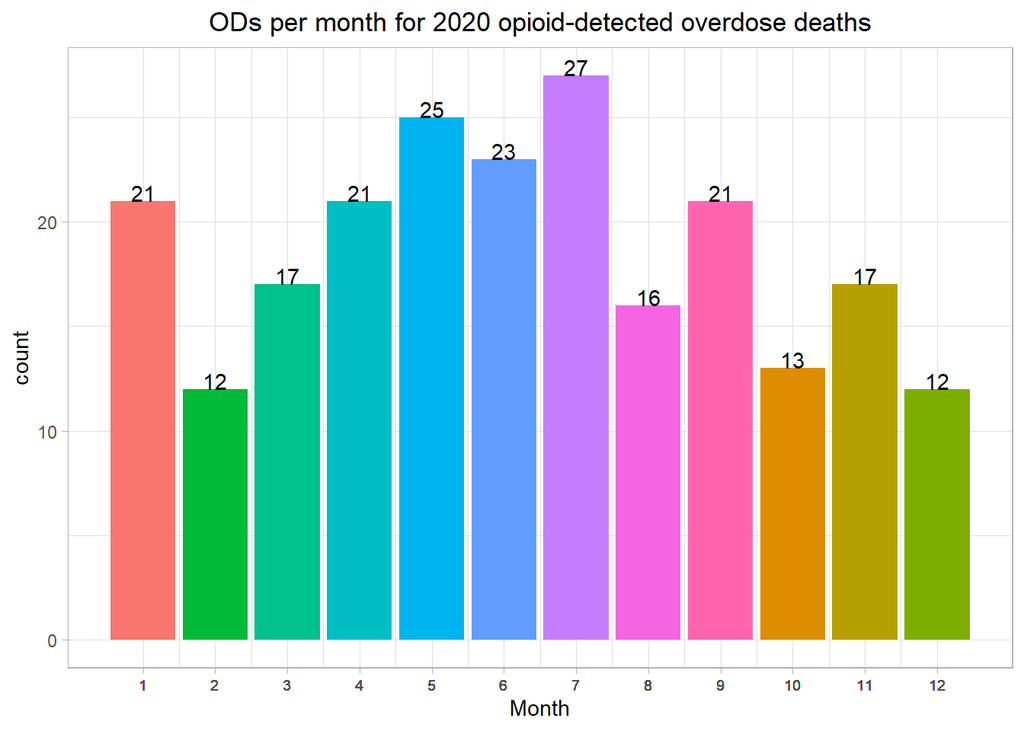

#### 2021

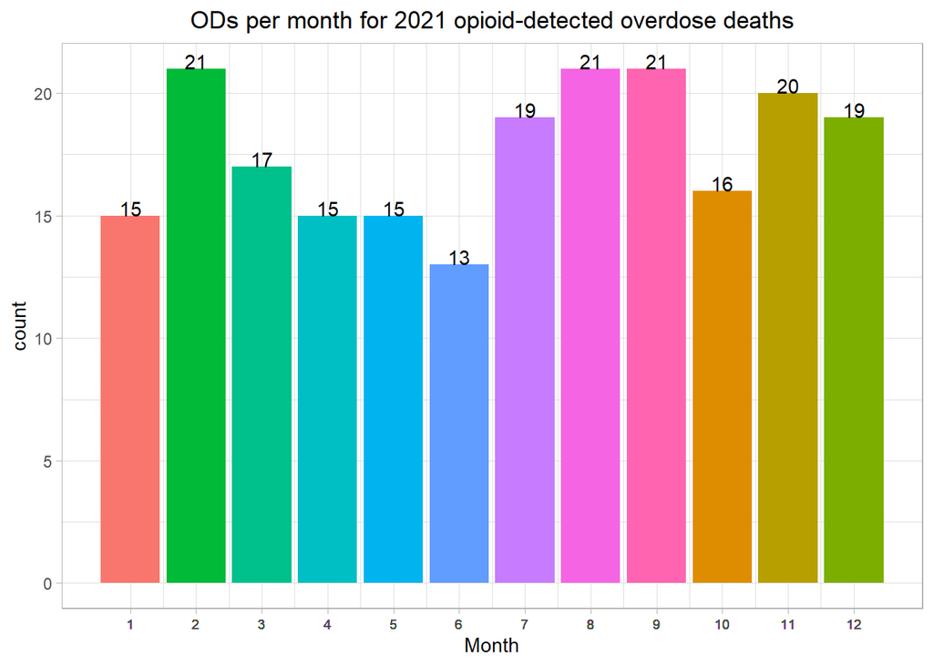

#### 2022

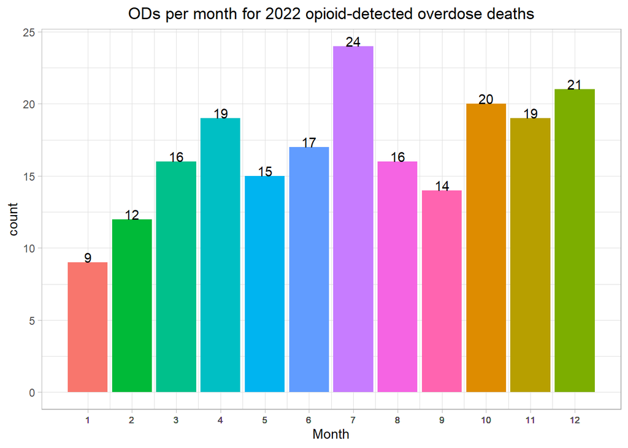

#### 2023

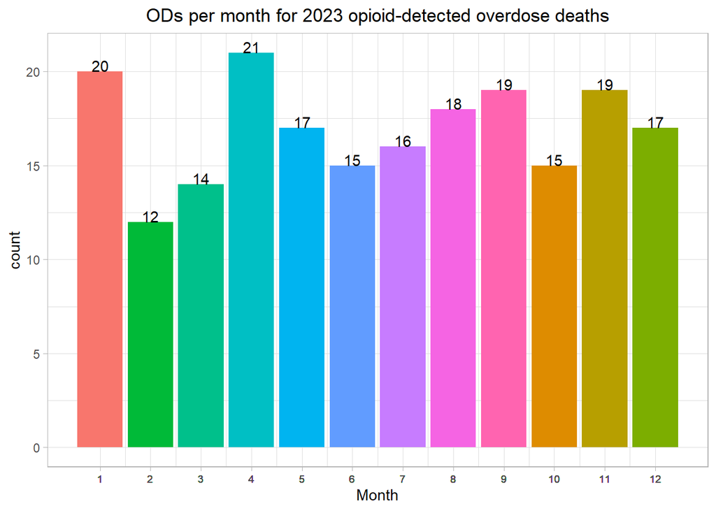

### Town of OD

To see these images in better resolution, right click and “open in new tab.” It may be more useful to see the corresponding version of these graphs in your DMHAS region of interest.

#### 2018

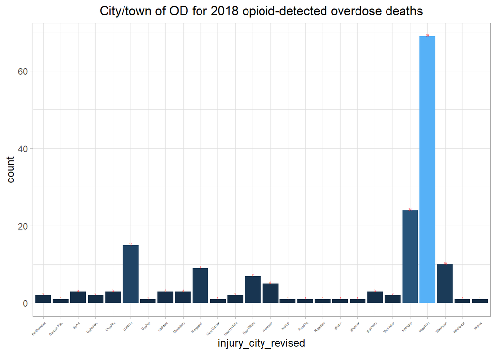

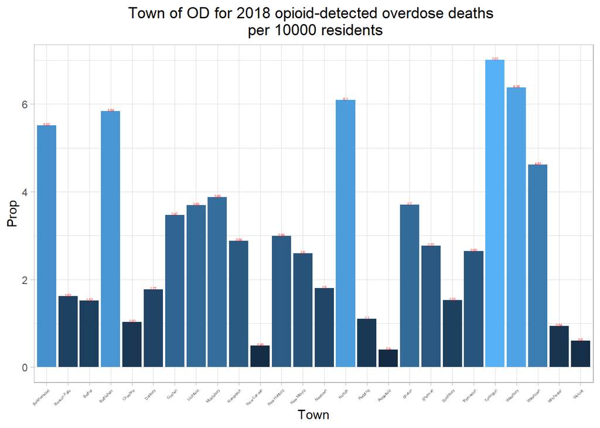

#### 2019

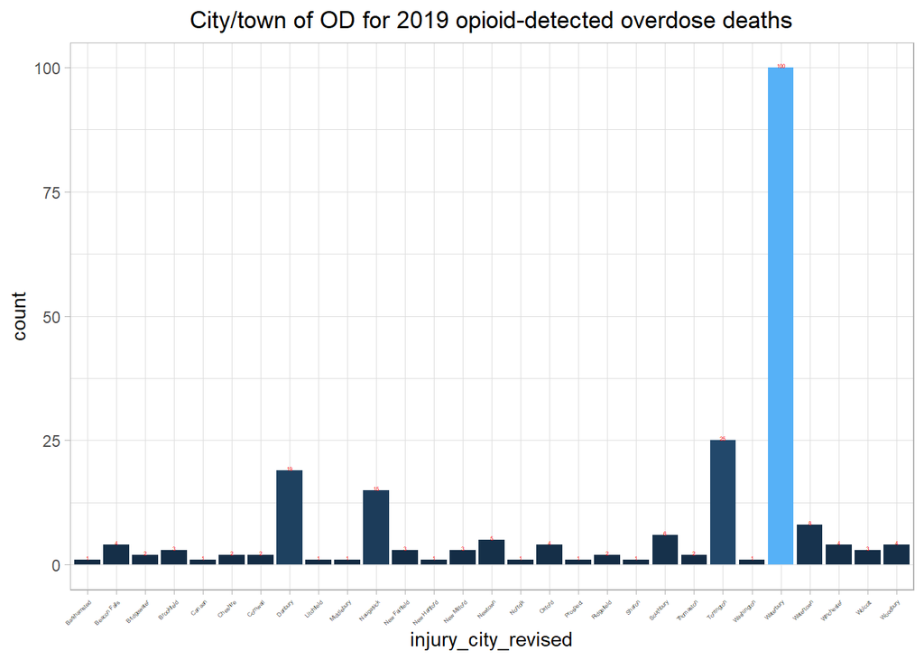

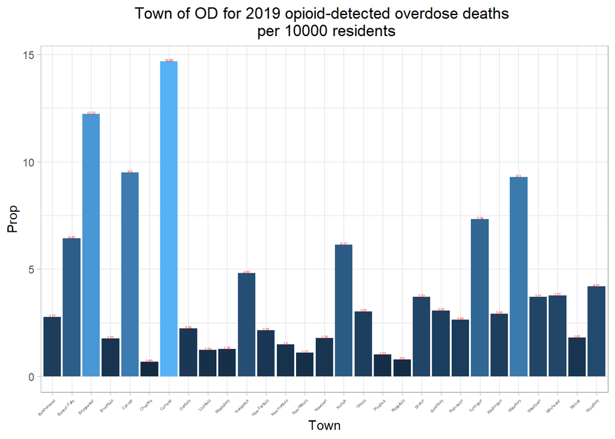

#### 2020

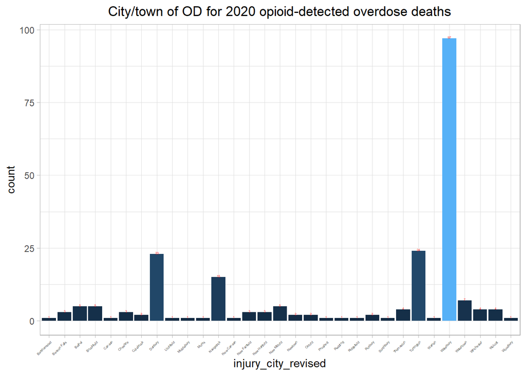

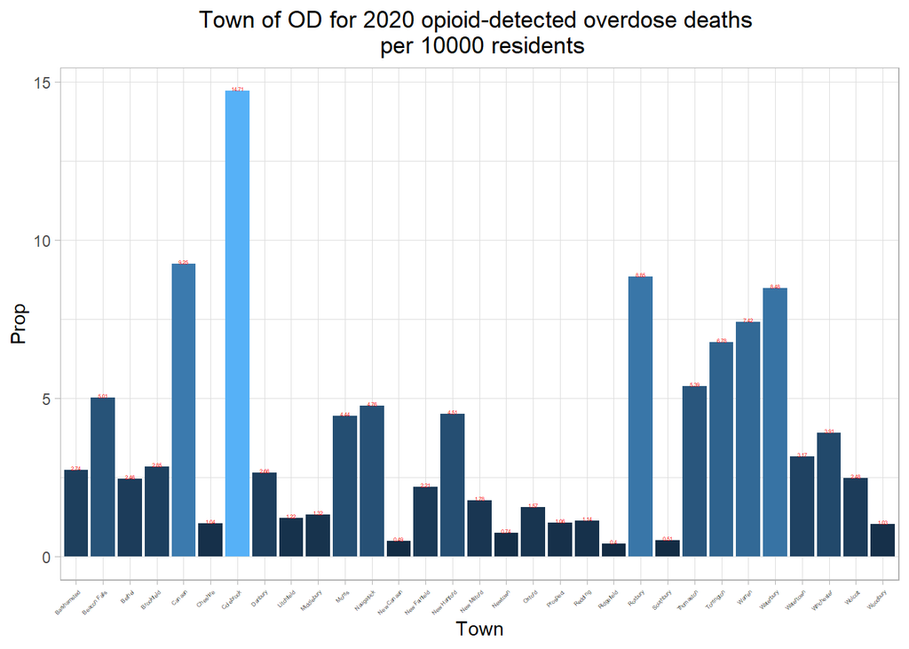

#### 2021

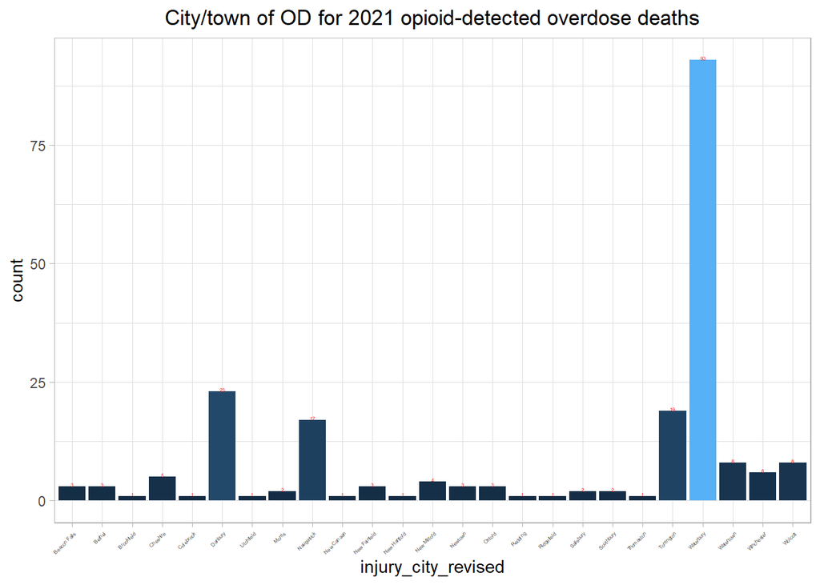

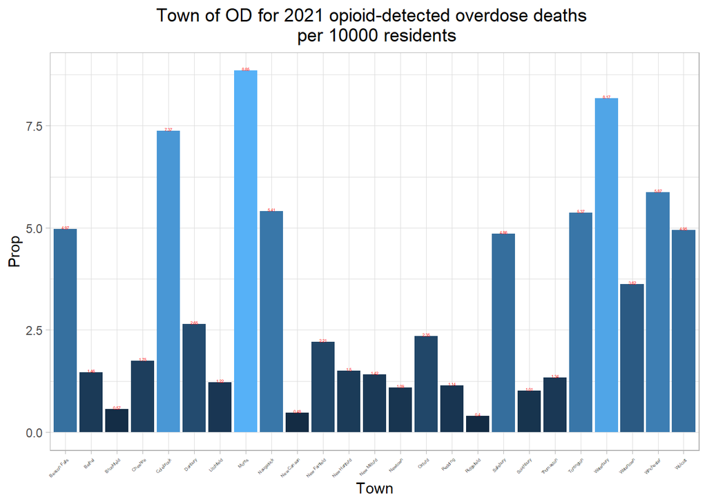

#### 2022

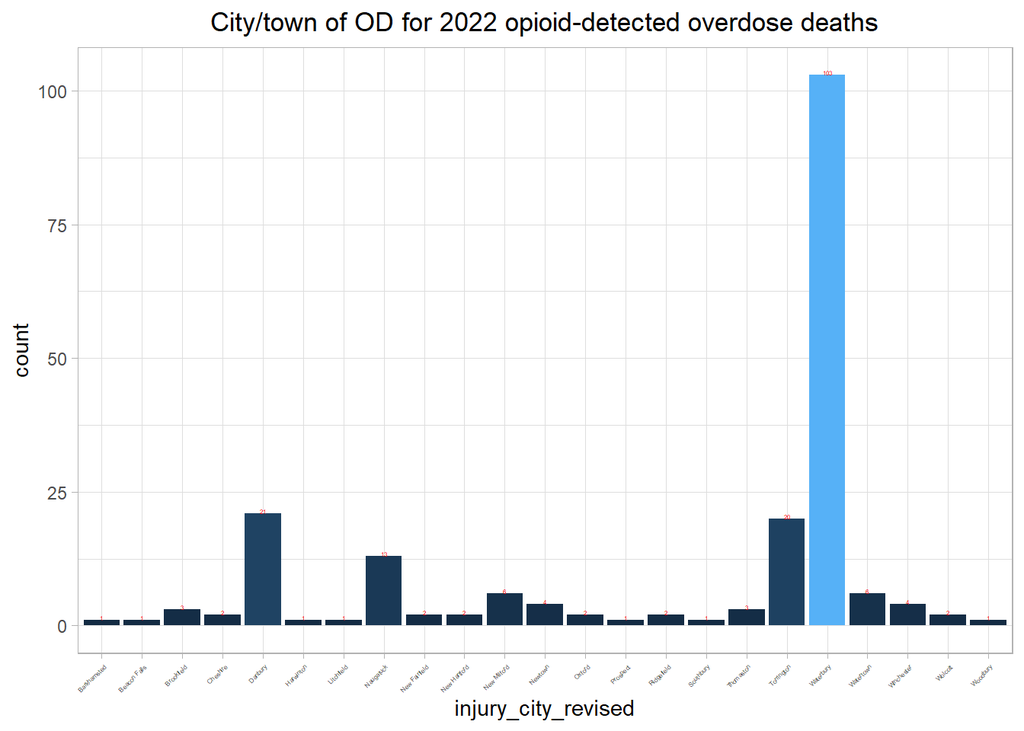

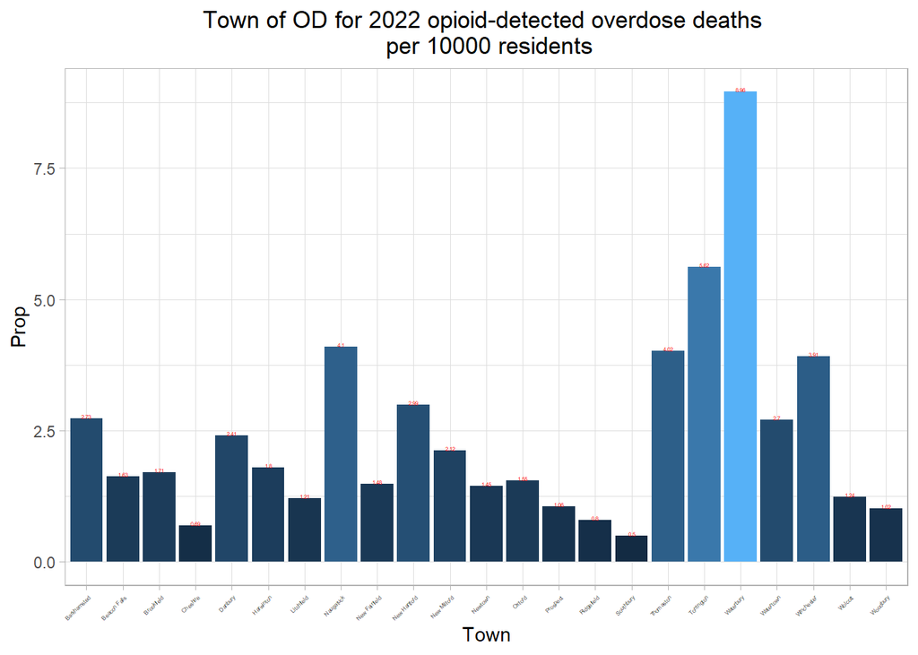

#### 2023

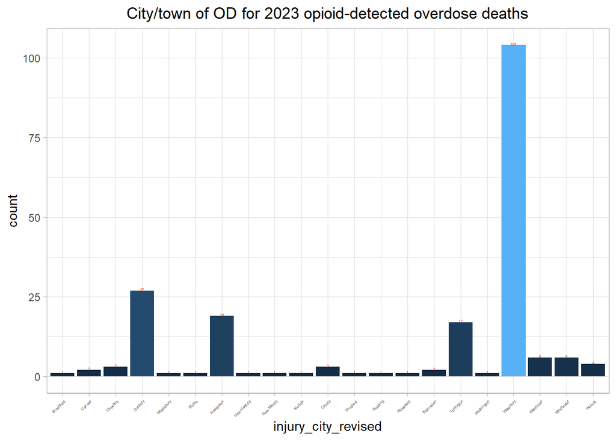

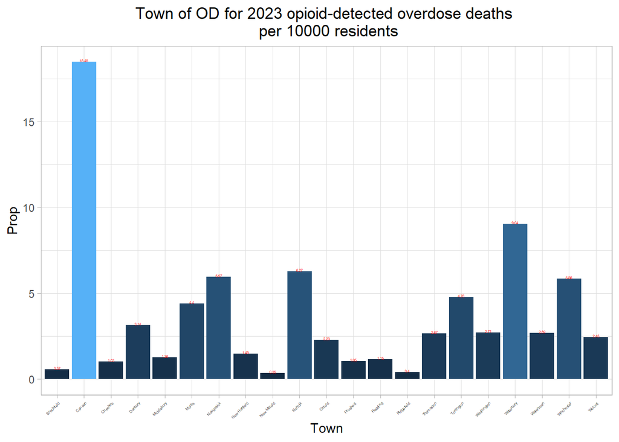

### Injury town v. residence town

I chose towns based on what regional harm reduction workers wanted and included, when I could, towns with overdose prevention infrastructure or towns with the most ODs in the past few years. I’m looking at instances where people who OD’d in a town didn’t live there [so they traveled to the town and OD’d there] – I am referring to this as “out-of-town ODs.”

#### 2018

```
## [1] "There were 18 instances where a person's residence town didn't match up with their injury town, out of 168 ODs in 2018 in region 5. This is 0.107143 of all ODs in this year."
```

```
## [1] "Here's a more in-depth look at out-of-town ODs in specific towns:"
```

```
##   Town name Out-of-town ODs Total ODs Proportion of out-of-town ODs
## 1   Danbury               3        15                           0.2
## 2 Waterbury               5        66                          0.08
```

#### 2019

```
## [1] "There were 32 instances where a person's residence town didn't match up with their injury town, out of 212 ODs in 2019 in region 5. This is 0.150943. "
```

```
## [1] "Here's a more in-depth look at out-of-town ODs in specific towns:"
```

```
##   Town name Out-of-town ODs Total ODs Proportion of out-of-town ODs
## 1   Danbury               3        16                          0.19
## 2 Waterbury              15        91                          0.16
```

#### 2020

```
## [1] "There were 27 instances where a person's residence town didn't match up with their injury town, out of 214 ODs in 2020 in region 5. This is 0.126168. "
```

```
## [1] "Here's a more in-depth look at out-of-town ODs in specific towns:"
```

```
##   Town name Out-of-town ODs Total ODs Proportion of out-of-town ODs
## 1   Danbury               2        23                          0.09
## 2 Waterbury              12        87                          0.14
```

#### 2021

```
## [1] "There were 31 instances where a person's residence town didn't match up with their injury town, out of 205 ODs in 2021 in region 5. This is 0.151220. "
```

```
## [1] "Here's a more in-depth look at out-of-town ODs in specific towns:"
```

```
##   Town name Out-of-town ODs Total ODs Proportion of out-of-town ODs
## 1   Danbury               6        23                          0.26
## 2 Waterbury              12        88                          0.14
```

#### 2022

```
## [1] "There were 35 instances where a person's residence town didn't match up with their injury town, out of 198 ODs in 2022 in region 5. This is 0.176768. "
```

```
## [1] "Here's a more in-depth look at out-of-town ODs in specific towns:"
```

```
##   Town name Out-of-town ODs Total ODs Proportion of out-of-town ODs
## 1   Danbury               4        21                          0.19
## 2 Waterbury              18        99                          0.18
```

#### 2023

```
## [1] "There were 30 instances where a person's residence town didn't match up with their injury town, out of 196 ODs in 2023 where the injury and residence town were both known. This is 0.153061 of all such ODs in this year."
```

```
## [1] "Here's a more in-depth look at out-of-town ODs in specific towns:"
```

```
##   Town name Out-of-town ODs Total ODs Percent of out-of-town ODs
## 1   Danbury               1        27                        3.7
## 2 Waterbury              21        98                       21.4
```

### Injury location

Please note that I have taken the original OCME data and aggregated the injury location categories somewhat [e.g. “wooded area” and “outdoors” are both listed under “outdoors”].

#### 2018

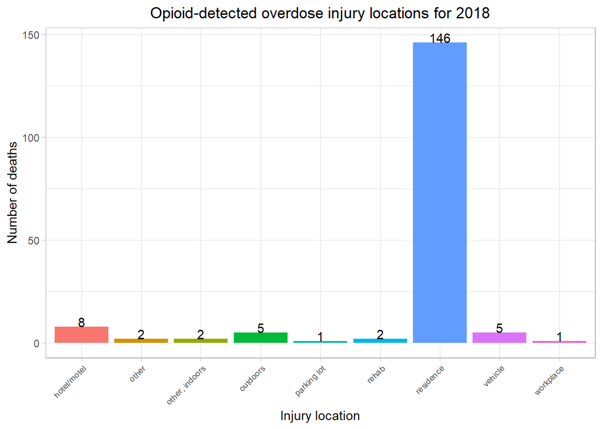

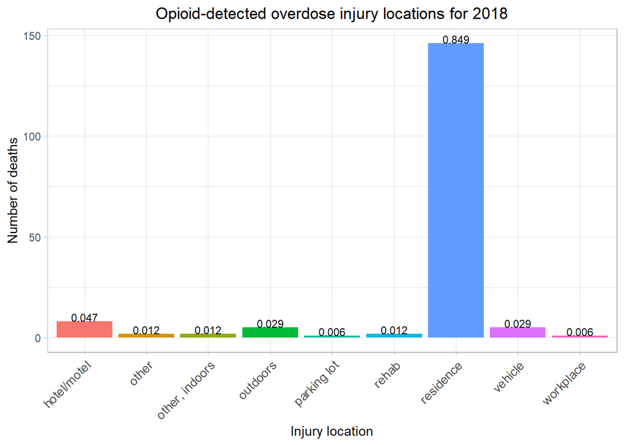

#### 2019

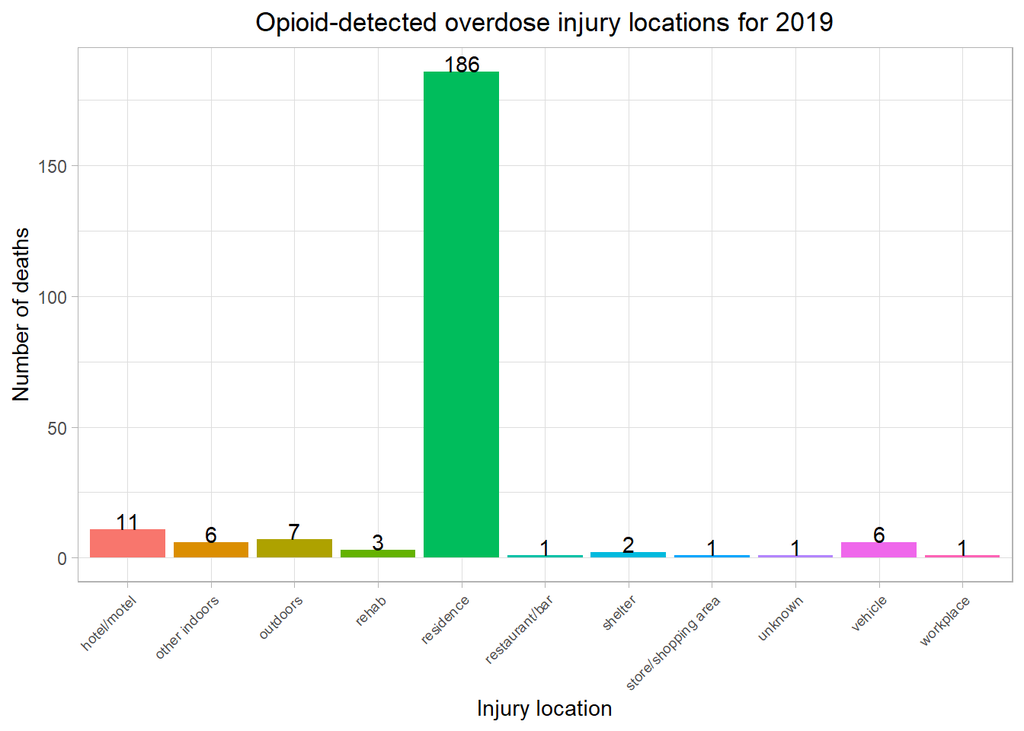

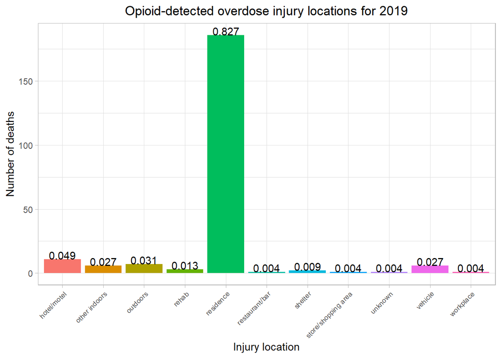

#### 2020

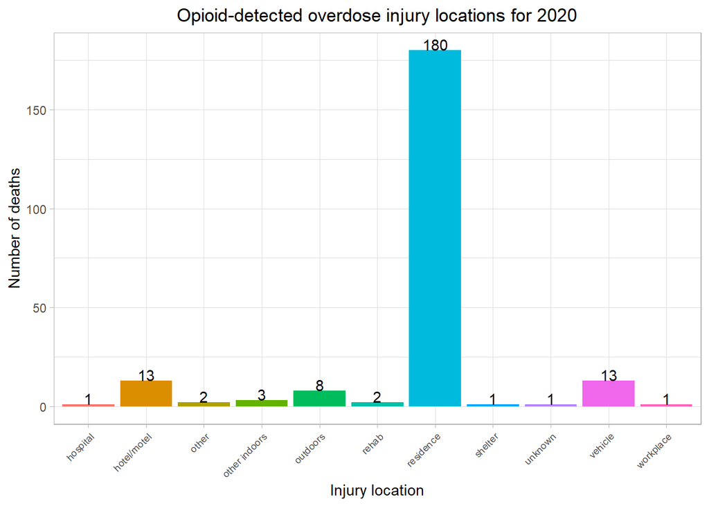

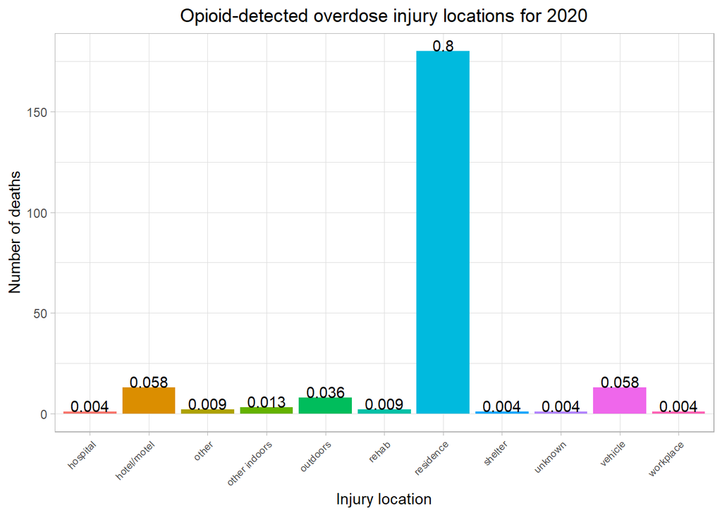

#### 2021

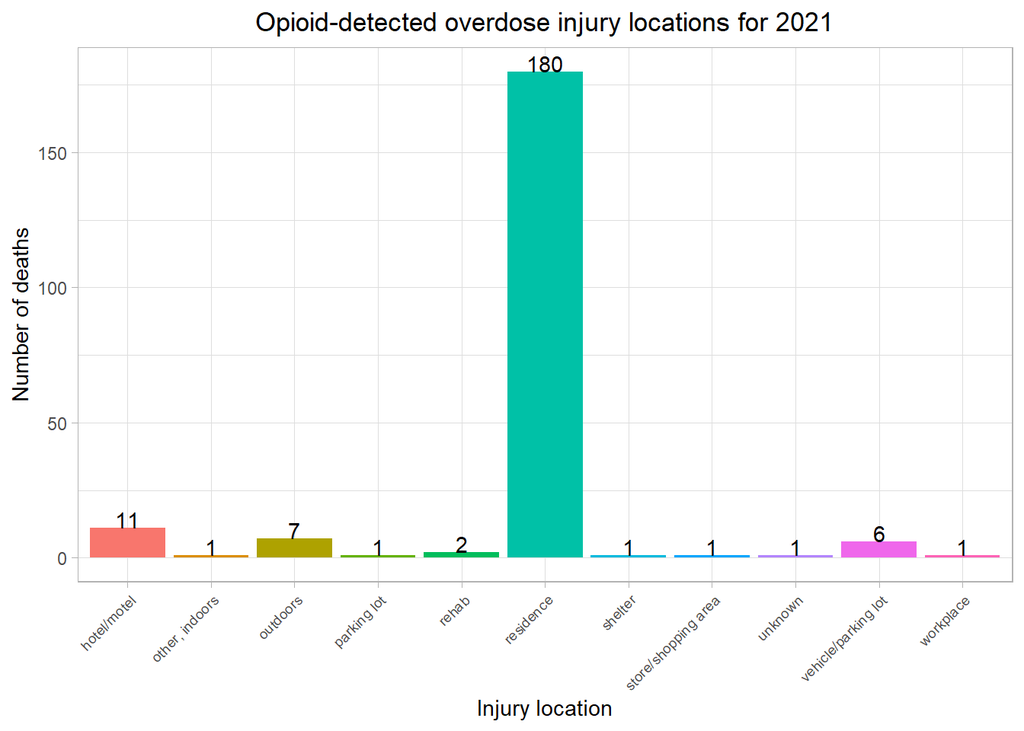

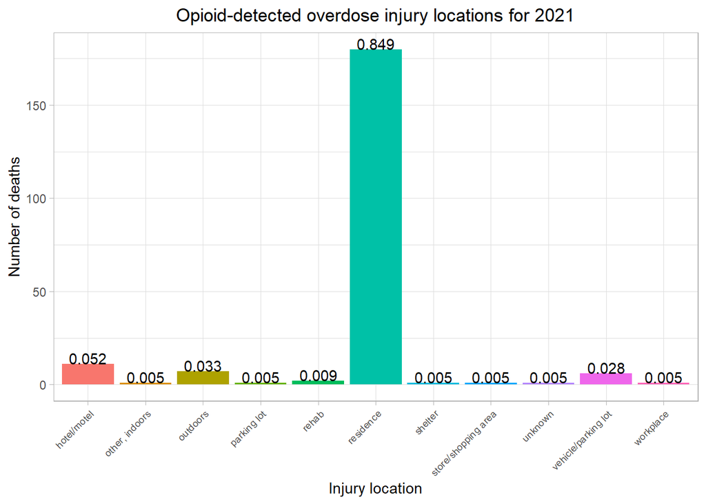

#### 2022

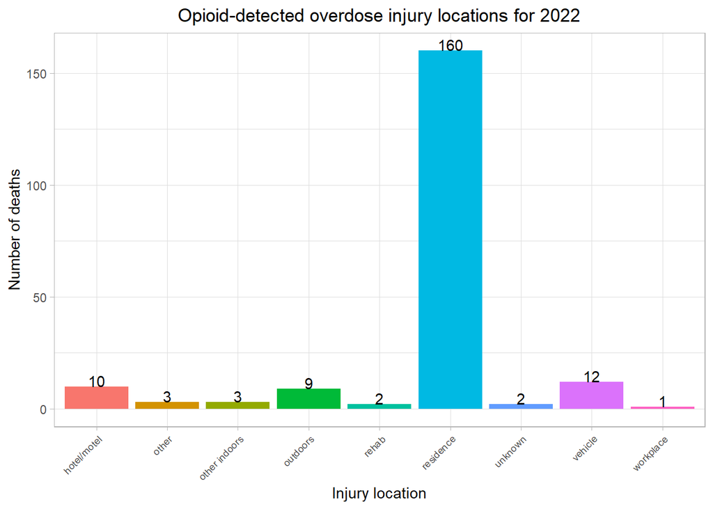

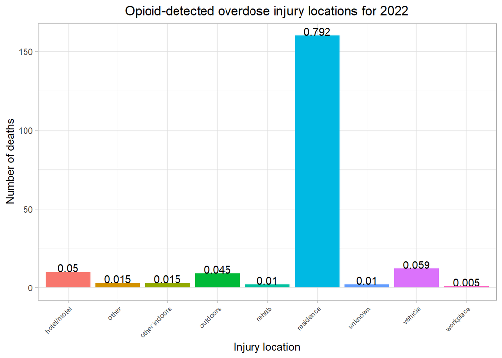

#### 2023

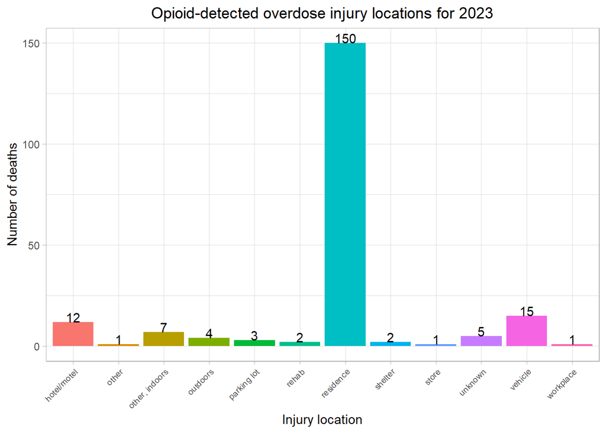

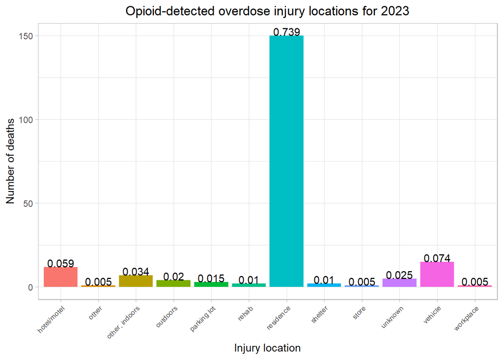

### Are people dying in their own homes?

Most deaths occur in some sort of residence. I check to see how many deaths have the same injury and residence address, which would mean that the decedent died at home.

#### 2018

```
## [1] "There were 122 people who OD'd in their own residence."
```

```
## [1] "The total proportion of decedents ODing in their own residence was 0.709302."
```

```
## [1] "Out of everyone who OD'd in a residence, 0.835616 of people OD'd in their own residence."
```

#### 2019

```
## [1] "There were 144 people who OD'd in their own residence."
```

```
## [1] "The proportion of decedents ODing in their own residence was 0.640000."
```

```
## [1] "Out of everyone who OD'd in a residence, 0.774194 of people OD'd in their own residence."
```

#### 2020

```
## [1] "There were 151 people who OD'd in their own residence."
```

```
## [1] "The proportion of decedents ODing in their own residence was 0.671111."
```

```
## [1] "Out of everyone who OD'd in a residence, 0.838889 of people OD'd in their own residence."
```

#### 2021

```
## [1] "There were 150 people who OD'd in their own residence."
```

```
## [1] "The proportion of decedents ODing in their own residence was 0.707547."
```

```
## [1] "Out of everyone who OD'd in a residence, 0.833333 of people OD'd in their own residence."
```

#### 2022

```
## [1] "There were 136 people who OD'd in their own residence."
```

```
## [1] "The proportion of decedents ODing in their own residence was 0.673267."
```

```
## [1] "Out of everyone who OD'd in a residence, 0.850000 of people OD'd in their own residence."
```

#### 2023

```
## [1] "There were 129 people who OD'd in their own residence."
```

```
## [1] "The proportion of decedents ODing in their own residence was 0.635468."
```

```
## [1] "Out of everyone who OD'd in a residence, 0.860000 of people OD'd in their own residence."
```

### Proportion of deaths with substances present

Upon request, I am sharing the proportion of deaths with the following substances detected in tox: fentanyl, pharmaceutical opioids [there is a “pharma” category in the data], xylazine, alcohol and gabapentin/pregabalin. I combine gabapentin and pregabalin based on danbury’s recommendation since they are part of the same drug class. More tox data for 2009-2023 to be published in the future!

#### Fentanyl

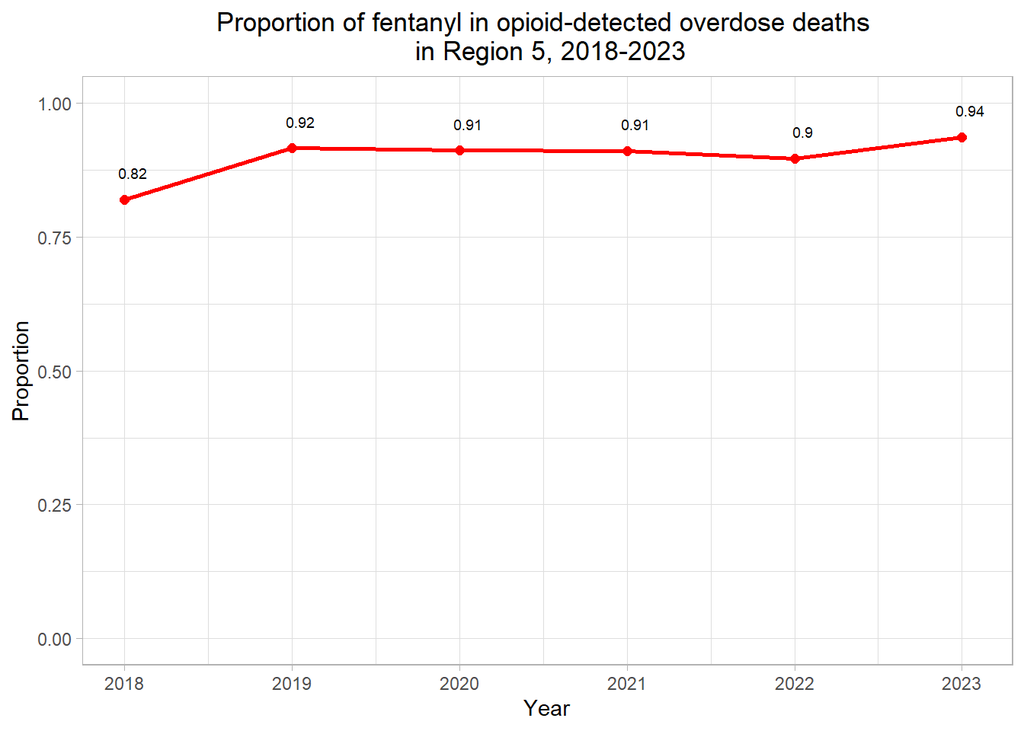

#### Pharmaceutical opioids

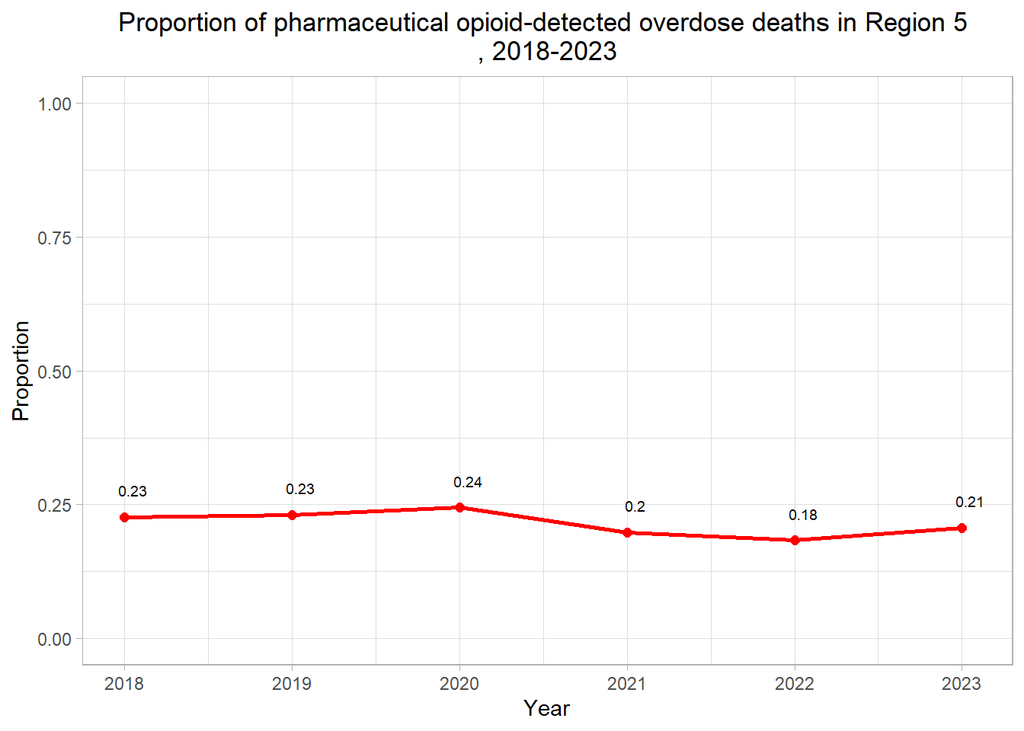

#### Xylazine

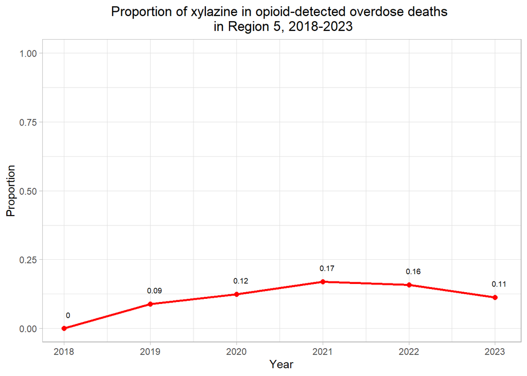

#### Alcohol

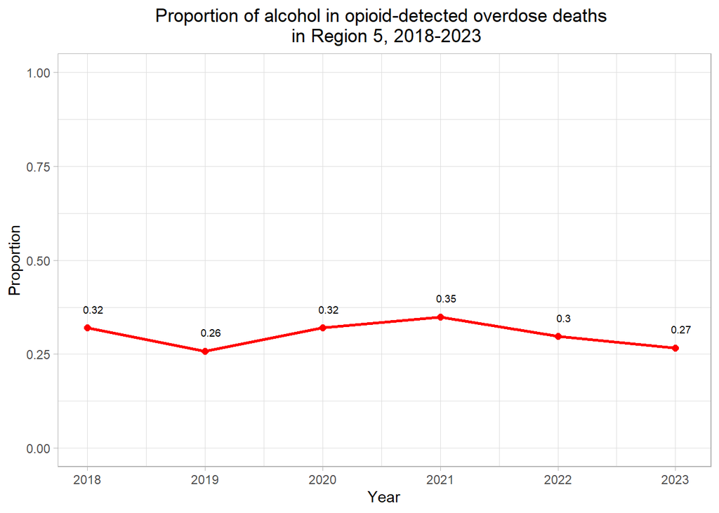

#### Gabapentin/pregabalin

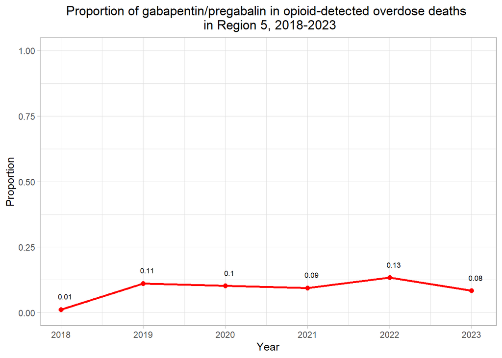

### Top 5 substance combinations by year

These are substance combinations found within the same decedent based on their tox report. “Other” is a catch-all category the OCME data uses to identify substances that are uncommon/not usually looked for in a tox report for an accidental overdose [e.g. benadryl, prescriptions for an unrelated condition].

#### 2018

[output not shown]

[output cut: 19 more lines]

The top 5 substance combinations for 2018 are:

1. fentanyl
2. cocaine, fentanyl
3. fentanyl, other
4. cocaine, fentanyl, other
5. fentanyl, alcohol

#### 2019

[output not shown]

[output cut: 20 more lines]

The top 5 substance combinations for 2019 are:

1. fentanyl, cocaine
2. fentanyl
3. fentanyl, alcohol
4. fentanyl, cocaine, other
5. fentanyl, other

#### 2020

[output not shown]

[output cut: 19 more lines]

The top 5 substance combinations for 2020 are:

1. fentanyl, cocaine
2. fentanyl
3. fentanyl, other, cocaine
4. fentanyl, alcohol
5. fentanyl, other

#### 2021

[output not shown]

[output cut: 19 more lines]

The top 5 substance combinations for 2021 are:

1. fentanyl, other, cocaine
2. fentanyl, cocaine
3. fentanyl, other
4. fentanyl
5. fentanyl, other, cocaine, alcohol

#### 2022

[output not shown]

[output cut: 19 more lines]

The top 5 substance combinations for 2022 are:

1. fentanyl, other, cocaine
2. fentanyl, cocaine
3. fentanyl, other
4. fentanyl, cocaine, alcohol
5. fentanyl, other, cocaine, alcohol

#### 2023

[output not shown]

[output cut: 19 more lines]

1. fentanyl, cocaine
2. fentanyl, other, cocaine
3. fentanyl, cocaine, alcohol
4. fentanyl
5. fentanyl, other

### How many people were using chronically?

This is based on request and should not be used for anything but a rough indication of chronic use. I identify chronic users crudely and approximately – I look for entries where the words “chronic” [can sometimes also indicate chronic pain, meaning opioid scripts], “Chronic”, “drug use”, “drug user”, “drug abuse”, “snort”, “snorts”, “addict”, “addicted”, “rehab”, or “sober house” pops up in either the notes field or immediate cause of death, because that generally means that the person had chronic drug use [based on my look at the data, I am including alcohol in chronic use].

#### 2018

```
## [1] "There were at least 29 people with suspected chronic use out of 172 decedents in 2018, which is 16.860465 percent of all decedents."
```

#### 2019

```
## [1] "There were at least 54 people with suspected chronic use out of 225 decedents in 2019, which is 24.000000 percent of all decedents."
```

#### 2020

```
## [1] "There were at least 61 people with suspected chronic use out of 225 decedents in 2020, which is 27.111111 percent of all decedents."
```

#### 2021

```
## [1] "There were at least 60 people with suspected chronic use out of 212 decedents in 2021, which is 28.301887 percent of all decedents."
```

#### 2022

```
## [1] "There were at least 105 people with suspected chronic use out of 202 decedents in 2022, which is 51.980198 percent of all decedents."
```

#### 2023

```
## [1] "There were at least 49 people with suspected chronic use out of 203 decedents in 2023, which is 24.137931 percent of all decedents."
```

### Who did decedents live with?

**Please note: this field and all fields explored below are only available in the data up to 2020.**

#### 2018

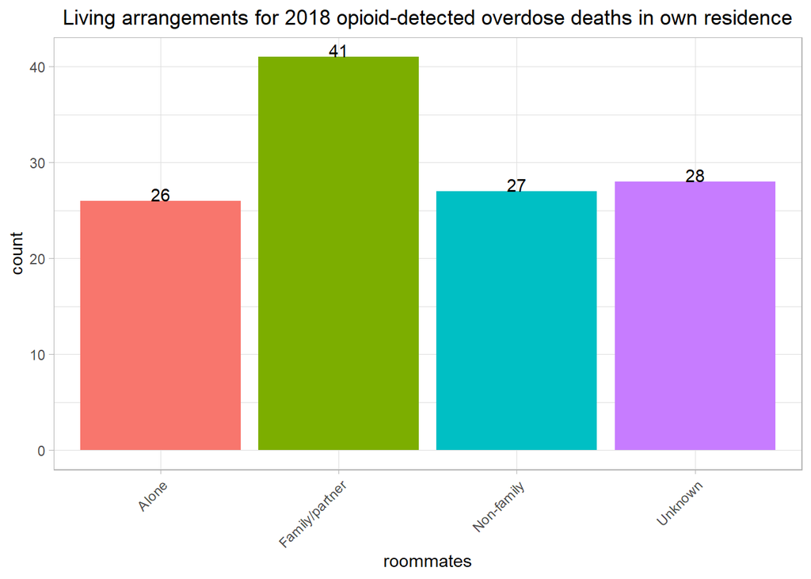

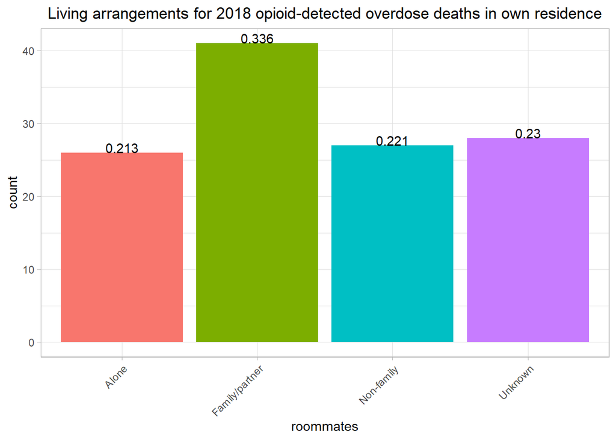

#### 2019

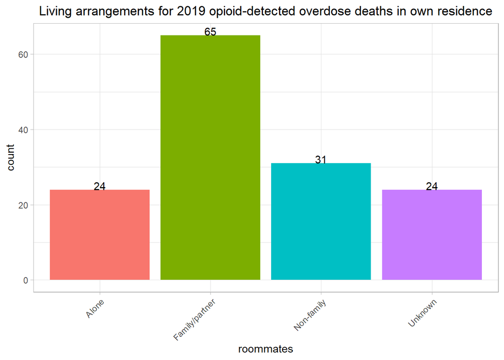

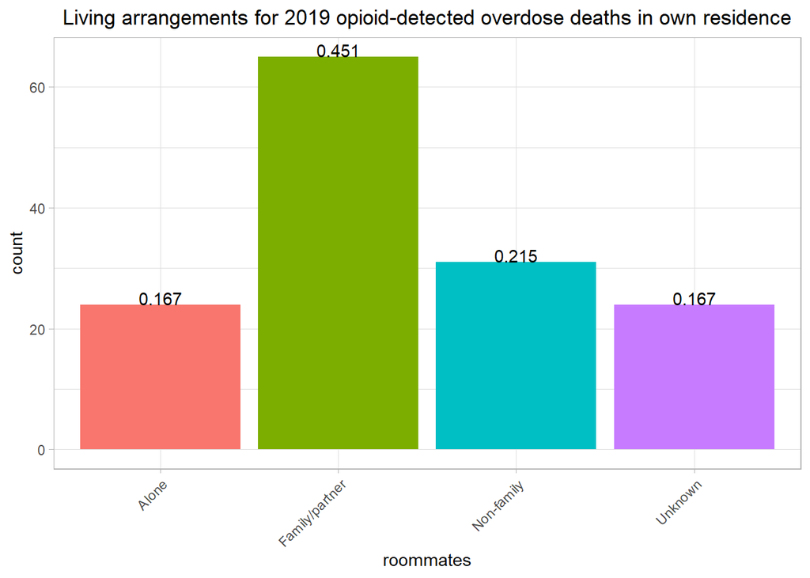

#### 2020

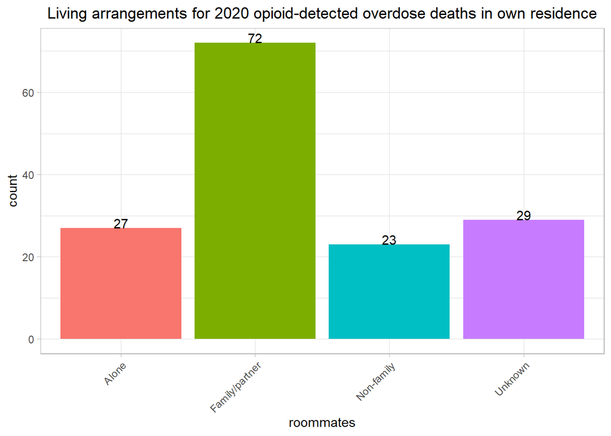

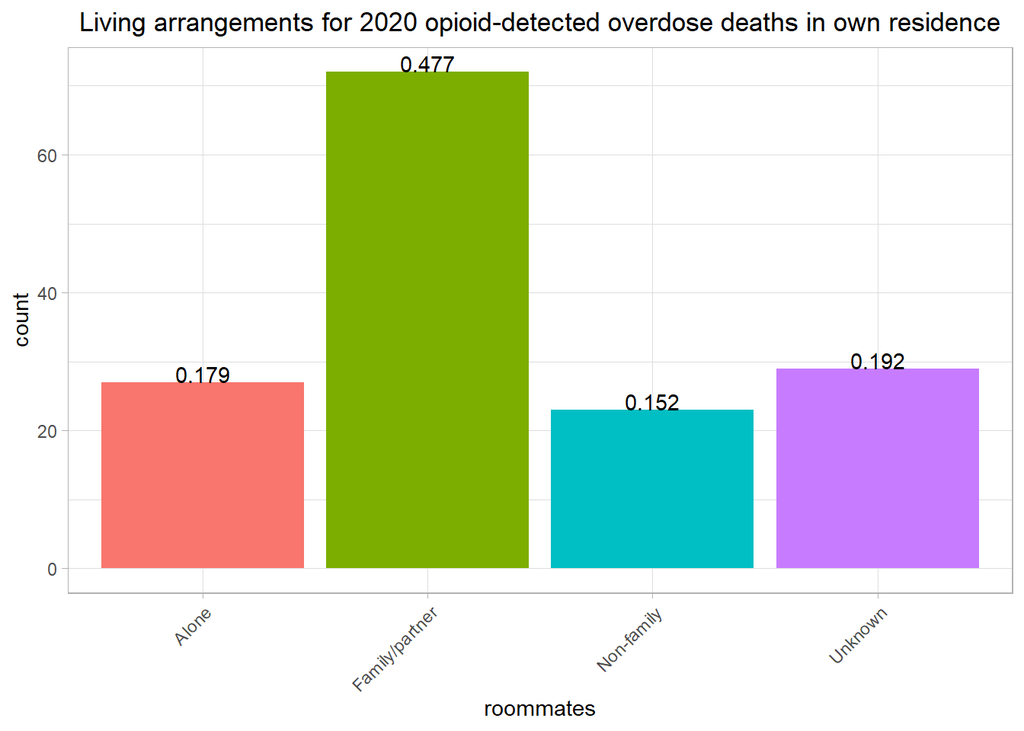

### % cases found in <24h and >=24h

Please note that this is an estimation based on the death narrative – it’s calculated as $\text{Time last known alive} - \text{time when the body was found}$. The last known alive time is based on witness statements and may be an overestimation, especially in cases where friends and family had not seen the decedent in a number of weeks/months.

#### 2018

```
## [1] "There were 127 people found within 24 hours, which is 0.738372 of all decedents."
```

```
## [1] "There were 25 people found in over 24 hours, which is 0.145349 of all decedents."
```

#### 2019

```
## [1] "There were 172 people found within 24 hours, which is 0.764444 of all decedents."
```

```
## [1] "There were 43 people found in over 24 hours, which is 0.191111 of all decedents."
```

#### 2020

```
## [1] "There were 175 people found within 24 hours, which is 0.777778 of all decedents."
```

```
## [1] "There were 30 people found in over 24 hours, which is 0.133333 of all decedents."
```